# DS_Assignment_03

Ankit

29/10/2021

### Collaborators: Alwin Eldhose, Srishti Dubey, Brinda Sarkar and Sakshi Abhyankar

# Scrape the web

## 1.1 Ethical issues

### 1.1.1

Wikipedia aims to empower people by generating and providing free and useful information. It allows scrapping to the user who are not using the data unethically. People can read and write article for free of charge and can contribute to the community as well.

### 1.1.2

I checked Wikipedia’s robots.txt page: https://en.wikipedia.org/robots.txt and found out that its scrapping friendly for users who are not using the scrapped data unethically.

### 1.1.3

To reduce the burden on wikipedia page:

- While scrapping the pages, I’ll parse it slowly so that Wikipedia page doesn’t crash.
- I’ll add delays while scrapping so that it doesn’t add pressure on Wikipedia server.
- I won’t hit on the page regularly and will use cached data.

## 1.2 Parse the list of mountains

### 1.2.1

```r
#Importing Libraries

library(rvest)
library(xml2)
library(tidyverse)
```

### 1.2.1

```r
mountains <- read_html("https://en.wikipedia.org/wiki/List_of_mountains_by_elevation") #reading Wikipedia page of list of mountains using read_html function
```

### 1.2.2

```r
mountains_table <- mountains %>% html_elements("table") #getting all the tables from the page
```

### 1.2.3

```r
table_header <- mountains %>% html_elements("th") %>% html_text() %>% cat() #getting heads of all the tables in the page
```

```
## Mountain Metres Feet Range Location and Notes
##  Mountain Metres Feet Range Location and Notes
##  Mountain Metres Feet Location and Notes
##  Mountain Metres Feet Range Location and Notes
##  Mountain Metres Feet Location and Notes
##  Mountain Metres Feet Location and Notes
##  Mountain Metres Feet Location and Notes
##  Mountain Metres Feet Location and Notes
##  Mountain Metres Feet Range Location and Notes
```

```r
# Just an example of how to extract links for individual mountains pages.

a <- mountains_table[[1]] %>% html_elements("tbody") %>% html_elements("tr")
for(y in 2:length(a)){
  print(a[y]%>% html_element("a") %>% html_attr("href"))
}
```

```
## [1] "/wiki/Mount_Everest"
## [1] "/wiki/K2"
## [1] "/wiki/Kangchenjunga"
## [1] "/wiki/Lhotse"
## [1] "/wiki/Makalu"
## [1] "/wiki/Cho_Oyu"
## [1] "/wiki/Dhaulagiri"
## [1] "/wiki/Manaslu"
## [1] "/wiki/Nanga_Parbat"
## [1] "/wiki/Annapurna"
## [1] "/wiki/Gasherbrum_I"
## [1] "/wiki/Broad_Peak"
## [1] "/wiki/Gasherbrum_II"
## [1] "/wiki/Shishapangma"
```

### 1.2.4

The dataframe everything is created with the columns as Mountain names, heights, and Wikipedia links. The dataframe contains 164 rows.

```r
Mountain_df <- NULL
a_href_df <- NULL

for(i in 1:length(mountains_table)){    #For loop, to create a dataframe of each table present in the wikipedia page

  x1 <- mountains_table[i]%>%html_table() %>% as.data.frame() %>% select("Mountain","Metres")
  Mountain_df <- rbind(Mountain_df,x1)
  x1$Metres <- gsub(",","",x1$Metres) %>% as.numeric()

  tr_mountain <- mountains_table[i] %>% html_elements("tbody") %>% html_elements("tr")

  for(y in 2:length(tr_mountain)){  # for loop to get all the from the webpage
    a_href <- tr_mountain[y]%>% html_element("a") %>% html_attr("href")
    a_href_df <- rbind(a_href_df,a_href)
    }
}

b<-as.data.frame(a_href_df)
everything <- cbind(Mountain_df,b)
everything$Metres <- gsub(",","",everything$Metres) %>% as.numeric()
everything <- everything[everything[,2]>=6800,]  #getting top mountains with height > 6800
rownames(everything) <- 1:nrow(everything)
everything <- everything %>%
  rename(
    Links = V1
    )
everything <- everything %>% mutate(Links = paste0("https://en.wikipedia.org/",everything$Links))
```

### 1.2.5

```r
everything %>% head(10) #Sample of the dataset we have created
```

```
##         Mountain Metres                                        Links
## 1  Mount Everest   8848 https://en.wikipedia.org//wiki/Mount_Everest
## 2             K2   8611            https://en.wikipedia.org//wiki/K2
## 3  Kangchenjunga   8586 https://en.wikipedia.org//wiki/Kangchenjunga
## 4         Lhotse   8516        https://en.wikipedia.org//wiki/Lhotse
## 5         Makalu   8485        https://en.wikipedia.org//wiki/Makalu
## 6        Cho Oyu   8188       https://en.wikipedia.org//wiki/Cho_Oyu
## 7     Dhaulagiri   8167    https://en.wikipedia.org//wiki/Dhaulagiri
## 8        Manaslu   8163       https://en.wikipedia.org//wiki/Manaslu
## 9   Nanga Parbat   8126  https://en.wikipedia.org//wiki/Nanga_Parbat
## 10     Annapurna   8091     https://en.wikipedia.org//wiki/Annapurna
```

## 1.3 Scrape the individual mountain data

### 1.3.1

```r
to_degree<-function(dimension) #Created a function to convert longitude and latitude to the degree
  {
     D <- if(grepl("[WS]", dimension)) -1 else 1
     dms <- try(strsplit(dimension, split ="°"),silent=TRUE)
     if(inherits(page, "try-error")){
         return("No Second")
     }
     dd <- as.numeric(dms[[1]][1])
     mm <- as.numeric(substring(dimension, 4,5))
     ss <- try(as.numeric(substring(dimension, 7,8)),silent=TRUE)
       if(inherits(page, "try-error")){
         return("No Second")
     }
     latitude1 <- (dd + mm/60 + ss/3600)*D
     return(latitude1)
}
```

### 1.3.2

```r
get_lat<-function(url)  #Created a function to get latitude from the link
  {
    if(is.na(url)){
      return("No Link")
    }
    else{
      link_try <- try(read_html(url),silent=TRUE)
      if(inherits(page, "try-error")){
        return("No Link")
      }

      mount_latitude <- try(link_try %>% html_element('span.latitude') %>% html_text(),silent=TRUE)
      if(inherits(page, "try-error")){
        return("No Link")
      }
      latitude <- to_degree(mount_latitude)
      return(latitude)
    }
}
```

```r
get_long<-function(url)   #Created a function to get longitude from the link
  {
   if(is.na(url)){
      return("No Link")
    }
    else{
      link_try <- try(read_html(url),silent=TRUE)
      if(inherits(page, "try-error")){
        return("No Link")
      }

      mount_longitude <- try(link_try %>% html_element('span.longitude') %>% html_text(),silent=TRUE)
      if(inherits(page, "try-error")){
        return("No Link")
      }
      longitude <- to_degree(mount_longitude)
      return(longitude)
    }
  }
```

### 1.3.3

```r
for(i in 1:length(everything$Links)){   # looping through the links of the individual mountains to get longitude and latitude of each mountain
  everything$Longitute[i] <- get_long(everything$Links[i])
  everything$Latitude[i] <- get_lat(everything$Links[i])
}
```

### 1.3.4

```r
everything%>%head(10)  #Sample of the final dataset
```

```
##         Mountain Metres                                        Links Longitute
## 1  Mount Everest   8848 https://en.wikipedia.org//wiki/Mount_Everest  86.92528
## 2             K2   8611            https://en.wikipedia.org//wiki/K2  76.51333
## 3  Kangchenjunga   8586 https://en.wikipedia.org//wiki/Kangchenjunga  88.14667
## 4         Lhotse   8516        https://en.wikipedia.org//wiki/Lhotse  86.93333
## 5         Makalu   8485        https://en.wikipedia.org//wiki/Makalu  87.08889
## 6        Cho Oyu   8188       https://en.wikipedia.org//wiki/Cho_Oyu  86.66083
## 7     Dhaulagiri   8167    https://en.wikipedia.org//wiki/Dhaulagiri  83.48750
## 8        Manaslu   8163       https://en.wikipedia.org//wiki/Manaslu  84.56194
## 9   Nanga Parbat   8126  https://en.wikipedia.org//wiki/Nanga_Parbat  74.58917
## 10     Annapurna   8091     https://en.wikipedia.org//wiki/Annapurna  83.82028
##    Latitude
## 1  27.98806
## 2  35.88250
## 3  27.70250
## 4  27.96167
## 5  27.88972
## 6  28.09417
## 7  28.69833
## 8  28.54944
## 9  35.23750
## 10 28.59611
```

## 1.4 Plot the mountains

### 1.4.1

For plotting the graph, we are using a separate library “maps”. By using world map data we are creating a world data which have region wise latitude and longitude which helps us create a blank map with scale. Then we separate geom plots to plot mountains in the graph.

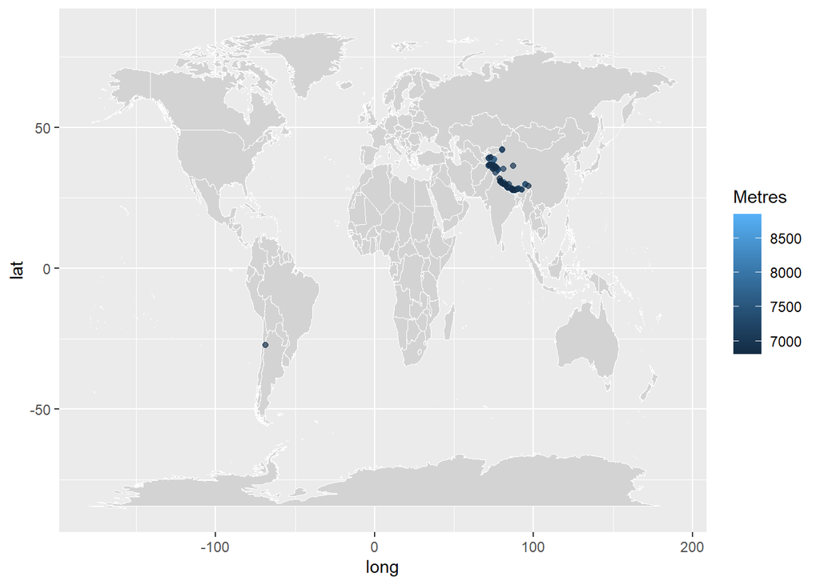

```r
#install.packages("maps")
library(maps)
world <- map_data("world")
ggplot()+geom_map(
data=world, map=world,
aes(long, lat, map_id=region),
color="white", fill="lightgray", size=0.1
)+
geom_polygon(col="white", fill="gray") +
geom_point(data=everything, aes(Longitute, Latitude, color=Metres),alpha=0.7)
```

### 1.4.2

I can see most of the highest mountains are in Asia and very close to Himalayan range which is actually true if we Google it and one of the tallest mountains is in Chile as well.

The tallest mountain(Mt.Everst) is located in Himalayan ranages in Asia in Nepal.

All the mountains we have plotted make sense to me as the highest mountain range(across globe) is in Asian in Nepal and almost all the mountains we plotted is in that range.

### I have worked for 10 hours on the dataset.